# Nichtlineare Optimierung -- steepest descent

**Manfred Brill, Hochschule Kaiserslautern**

## Vorbemerkungen

In der Vorlesung hatten wir eine generische Formulierung für Abstiegsverfahren formuliert und als konkrete Realisierung *steepest descent* formuliert. Wir hatten den Verlauf dieses Verfahrens an Hand einer quadratischen Form visualisiert. In diesem Notebook finden wir die Berechnungen und Visualisierungen mit dem dazu gehörenden Python-Code.

## Ein Beispiel

Wir implementieren die quadratische Form als Zielfunktion f. Da wir die Gradienten der quadratischen Form benötigen implementieren wir auch gleich eine Funktion, die uns den Gradienten zurückgibt. Wir verwenden Konturlinien und erzeugen damit eine grafische Ausgabe der quadratischen Form. Hier erkennen wir bereits sehr gut, dass das gesuchte lokale Minimum im Ursprung liegt. Für das Iterationsverfahren verwenden wir den Startpunkt (1/2, 1/3), den wir gleich in die grafische Darstellung eintragen.

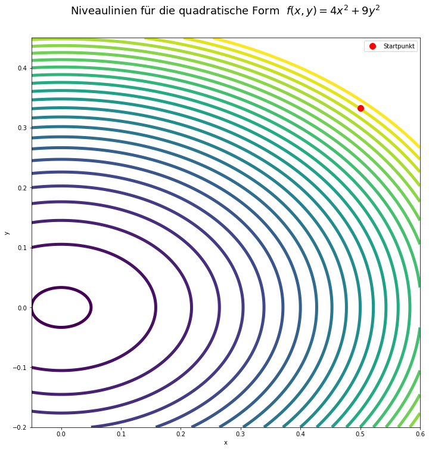

```python
import numpy as np
import matplotlib.pyplot as plt

def f(x, y):
    """
    Zielfunktion
    """
    return 4.0*x**2 + 9.0*y**2


def gradient(x, y):
    """ Gradient der Zielfunktion """
    return 8.0*x, 18.0*y


x0 = 0.5
y0 = 1.0/3.0

xmin = -0.05
xmax = 0.6
ymin = -0.2
ymax = 0.45

x = np.linspace(xmin, xmax, 200)
y = np.linspace(ymin, ymax, 200)
x, y = np.meshgrid(x, y)
z = f(x, y)

Cmin = 0.01
Cmax = 2.1
Cstep = 0.09
levels = np.arange(Cmin, Cmax, Cstep)

fig = plt.figure(figsize=(12.0, 12.0))
ax = fig.add_subplot(111)
ax.set_aspect('equal')
cplot = plt.contour(x, y, z,
                    levels=levels,
                    linewidths=5,
                    extent=(xmin, xmax, -ymin, ymax))
plt.plot(x0, y0, 'ro', markersize=10, label='Startpunkt')
plt.xlabel('x')
plt.ylabel('y')
plt.title('Niveaulinien für die quadratische Form  $f(x, y) = 4 x^2 +  9 y^2$',
          y=1.05, fontsize=18)
plt.legend()

plt.show()
```

## Steepest Descnt

Wir realisieren dieses Abstiegsverfahren selbst, da es als Methode in SciPy nicht angeboten wird. Das ist auch nicht schwierig. Für den Schritt der eindimensionalen Optimierung verwenden wir die Funktion *optimize_scalar* und den Brent-Algorithmus.

Wir implementieren eine Funktion, die einen Iterationsschritt von steepest descent ausführ und vorher noch die Zielfunktion, die wir in *optimize.minimize_scalar* einsetzen. Hier sieht man auch gut, wie wir mit Hilfe des Parameters *arg* weitere Parameter an die Zielfunktion übergeben können.

```python
from scipy import optimize

def oned_f(t, x, y, dx, dy):
    """
    Zielfunktion für die eindimensionale Optimierung
    """
    return f(x + t*dx, y + t*dy)


def sd_iteration(x0, y0, out=True):
    """
    Eine Iteration von Steepest Descent
    """
    d0x, d0y = gradient(x0, y0)
    d0x = -d0x
    d0y = -d0y
    result = optimize.minimize_scalar(oned_f,
                                      args=(x0, y0, d0x, d0y),
                                      bracket=(0.0, 10.0),
                                      options=({'maxiter': 50}))
    if result.success:
        t = result.x
        x1 = x0 + t*d0x
        y1 = y0 + t*d0y
    else:
        x1, y1 = 0.0, 0.0

    return x1, y1
```

Jetzt führen wir eine erste Iteration durch und geben dazu Werte auf der Konsole aus, bevor wir eine grafische Darstellung erstellen.

```python
print('Steepest Descent')
print('Exaktes lokales Minimum ist der Punkt (0,0)')
print('Funktionswert am lokalen Minimum:', f(0.0, 0.0))
print('Startpunkt:', x0, ',', y0)
print('Funktionswert am Startpunkt', f(x0, y0))

# Erste Iteration
print('\nErste Iteration')
x1, y1 = sd_iteration(x0, y0)
print('Die Näherung nach der ersten Iteration:', x1, ',', y1)
print('Funktionswert an diesem Punkt:', f(x1, y1))
```

```
Steepest Descent
Exaktes lokales Minimum ist der Punkt (0,0)
Funktionswert am lokalen Minimum: 0.0
Startpunkt: 0.5 , 0.3333333333333333
Funktionswert am Startpunkt 2.0

Erste Iteration
Die Näherung nach der ersten Iteration: 0.23195876288659678 , -0.06872852233677151
Funktionswert an diesem Punkt: 0.2577319587628866
```

```python
# Zweite Iteration
print('Zweite Iteration')
x2, y2 = sd_iteration(x1, y1)
print('Die Näherung nach der zweiten Iteration:', x2, ',', y2)
print('Funktionswert an diesem Punkt', f(x2, y2))

# Dritte Iteration
print('\nDritte Iteration')
x3, y3 = sd_iteration(x2, y2)
print('Die Näherung nach der dritten Iteration:', x3, ',', y3)
print('Funktionswert an diesem Punkt', f(x3, y3))

# Vierte Iteration
print('\nVierte Iteration')
x4, y4 = sd_iteration(x3, y3)
print('Die Näherung nach der vierten Iteration:', x4, ',', y4)
print('Funktionswert an diesem Punkt', f(x4, y4))
```

```
Zweite Iteration
Die Näherung nach der zweiten Iteration: 0.06443298969072353 , 0.04295532646048074
Funktionswert an diesem Punkt 0.03321288128387783

Dritte Iteration
Die Näherung nach der dritten Iteration: 0.029891593155489796 , -0.008856768342367913
Funktionswert an diesem Punkt 0.004280010474726632

Vierte Iteration
Die Näherung nach der vierten Iteration: 0.00830322032096981 , 0.0055354802139796645
Funktionswert an diesem Punkt 0.0005515477415885071
```

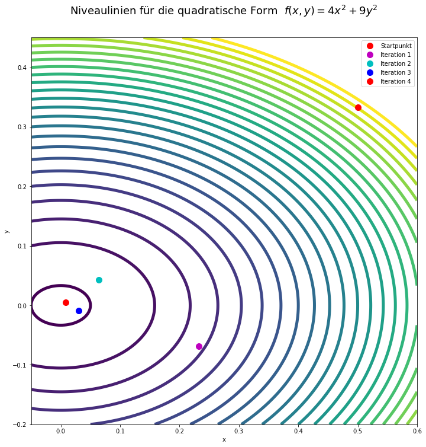

```python
fig = plt.figure(figsize=(12.0, 12.0))
ax = fig.add_subplot(111)
ax.set_aspect('equal')
cplot = plt.contour(x, y, z,
                    levels=levels,
                    linewidths=5,
                    extent=(xmin, xmax, -ymin, ymax))
plt.plot(x0, y0, 'ro', markersize=10, label='Startpunkt')
plt.plot(x1, y1, 'mo', markersize=10, label='Iteration 1')
plt.plot(x2, y2, 'co', markersize=10, label='Iteration 2')
plt.plot(x3, y3, 'bo', markersize=10, label='Iteration 3')
plt.plot(x4, y4, 'ro', markersize=10, label='Iteration 4')
plt.xlabel('x')
plt.ylabel('y')
plt.title('Niveaulinien für die quadratische Form  $f(x, y) = 4 x^2 +  9 y^2$',
          y=1.05, fontsize=18)
plt.legend()

plt.show()
```

Es gibt verschiedene Möglichkeiten den Verlauf des Iterationsverfahrens zu visualisieren. Wir können die einzelnen Näherungen mit Pfeilen verbinden um den Verlauf der Berechnungen klarer zu machen.

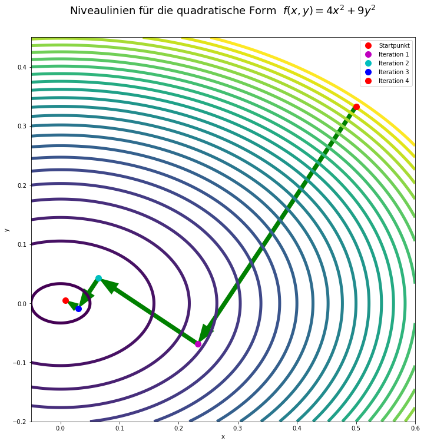

```python
fig = plt.figure(figsize=(12.0, 12.0))
ax = fig.add_subplot(111)
ax.set_aspect('equal')
cplot = plt.contour(x, y, z,
                    levels=levels,
                    linewidths=5,
                    extent=(xmin, xmax, -ymin, ymax))

plt.plot(x0, y0, 'ro', markersize=10, label='Startpunkt')
plt.plot(x1, y1, 'mo', markersize=10, label='Iteration 1')
plt.plot(x2, y2, 'co', markersize=10, label='Iteration 2')
plt.plot(x3, y3, 'bo', markersize=10, label='Iteration 3')
plt.plot(x4, y4, 'ro', markersize=10, label='Iteration 4')

plt.arrow(x0, y0, x1-x0, y1-y0,
          width=0.0075,
          fc='g',
          ec='none',
          length_includes_head=True)
plt.arrow(x1, y1, x2-x1, y2-y1,
          width=0.0075,
          fc='g',
          ec='none',
          length_includes_head=True)
plt.arrow(x2, y2, x3-x2, y3-y2,
          width=0.0075,
          fc='g',
          ec='none',
          length_includes_head=True)
plt.arrow(x3, y3, x4-x3, y4-y3,
          width=0.005,
          fc='g',
          ec='none',
          length_includes_head=True)

plt.xlabel('x')
plt.ylabel('y')
plt.title('Niveaulinien für die quadratische Form  $f(x, y) = 4 x^2 +  9 y^2$',
          y=1.05, fontsize=18)
plt.legend()

plt.show()
```